# Caractéristiques générales et logiques d’implantation des surfaces élémentaires de plans d’eau de la zone d’étude

Hélène ANQUETIL et Josselin BARRY

2024-09-26

### Caractéristiques générales des surfaces élémentaires de plans d’eau

#### Répartition par territoire et par type de surface élémentaire

| Territoire | Superficie (km²) | Superficie de marais retenue (km²) | Nombre total de plans d’eau | Densité de plans d’eau par Km² | Nombre de plans d’eau (hors mares et marais) | Densité de plans d’eau par Km² (hors mares et marais) | Nombre de mares (hors marais) | Densité de mares par Km² (hors marais) |
| --- | --- | --- | --- | --- | --- | --- | --- | --- |
| Bretagne et Pays-de-la-Loire | 59805 | 1700 | 177421 | 2.97 | 121529 | 2.09 | 36615 | 0.63 |
| Bretagne | 27446 | 144 | 45880 | 1.67 | 39034 | 1.43 | 6642 | 0.24 |
| Pays-de-la-Loire | 32359 | 1556 | 131541 | 4.07 | 82495 | 2.68 | 29973 | 0.97 |
| Côtes-d’Armor | 6975 | 0 | 7728 | 1.11 | 6656 | 0.95 | 1072 | 0.15 |
| Finistère | 6768 | 0 | 7748 | 1.14 | 6688 | 0.99 | 1060 | 0.16 |
| Ille-et-Vilaine | 6832 | 141 | 18516 | 2.71 | 15583 | 2.33 | 2746 | 0.41 |
| Loire-Atlantique | 6993 | 524 | 28922 | 4.14 | 17230 | 2.66 | 5958 | 0.92 |
| Maine-et-Loire | 7161 | 0 | 28561 | 3.99 | 20829 | 2.91 | 7732 | 1.08 |
| Mayenne | 5208 | 0 | 16617 | 3.19 | 13375 | 2.57 | 3242 | 0.62 |
| Morbihan | 6872 | 4 | 11888 | 1.73 | 10107 | 1.47 | 1764 | 0.26 |
| Sarthe | 6238 | 0 | 21864 | 3.50 | 14608 | 2.34 | 7256 | 1.16 |
| Vendée | 6759 | 1032 | 35577 | 5.26 | 16453 | 2.87 | 5785 | 1.01 |

#### Sur zones humides, sur cours, sur nappe, sur source …

Voici la répartition des surfaces élémentaires de plans d’eau selon leur lien avec le réseau hydrographique :

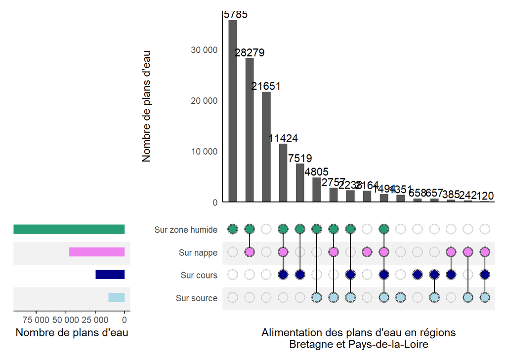

| Emprise | Nombre total de plans d’eau (hors mares et marais) | Nombre de plans d’eau en zone humide | % en zone humide | Nombre de plans d’eau connectés | % connecte | Nombre de plans d’eau sur nappe | % sur nappe | Nombre de plans d’eau sur cours | % sur cours | Nombre de plans d’eau sur source | % sur source |
| --- | --- | --- | --- | --- | --- | --- | --- | --- | --- | --- | --- |
| Zone d’étude | 143790 | 109552 | 76.19 | 73981 | 51.45 | 52711 | 36.66 | 29123 | 20.25 | 15845 | 11.02 |
| Bretagne et Pays-de-la-Loire | 121529 | 94301 | 77.60 | 64093 | 52.74 | 46865 | 38.56 | 24495 | 20.16 | 13664 | 11.24 |
| Pays-de-la-Loire | 82495 | 61739 | 74.84 | 41104 | 49.83 | 31132 | 37.74 | 14604 | 17.70 | 8527 | 10.34 |
| Bretagne | 39034 | 32562 | 83.42 | 22989 | 58.89 | 15733 | 40.31 | 9891 | 25.34 | 5137 | 13.16 |
| Côtes d’Armor | 6656 | 5235 | 78.65 | 3752 | 56.37 | 2319 | 34.84 | 1842 | 27.67 | 910 | 13.67 |
| Finistère | 6688 | 5052 | 75.54 | 3663 | 54.77 | 2870 | 42.91 | 1475 | 22.05 | 746 | 11.15 |
| Ille et Vilaine | 15583 | 13920 | 89.33 | 9153 | 58.74 | 6494 | 41.67 | 3511 | 22.53 | 1899 | 12.19 |
| Loire Atlantique | 17230 | 13798 | 80.08 | 7604 | 44.13 | 5602 | 32.51 | 2359 | 13.69 | 1734 | 10.06 |
| Mayenne | 13375 | 9706 | 72.57 | 7796 | 58.29 | 5103 | 38.15 | 3792 | 28.35 | 1897 | 14.18 |
| Morbihan | 10107 | 8355 | 82.67 | 6421 | 63.53 | 4050 | 40.07 | 3063 | 30.31 | 1582 | 15.65 |
| Sarthe | 14608 | 11219 | 76.80 | 7938 | 54.34 | 6550 | 44.84 | 1887 | 12.92 | 1209 | 8.28 |
| Vendée | 16453 | 11740 | 71.35 | 8025 | 48.78 | 6545 | 39.78 | 3244 | 19.72 | 1752 | 10.65 |

#### Superficie

A l’échelle de la zone d’étude, la distribution de la superficie des surfaces élémentaires de plans d’eau est la suivante :

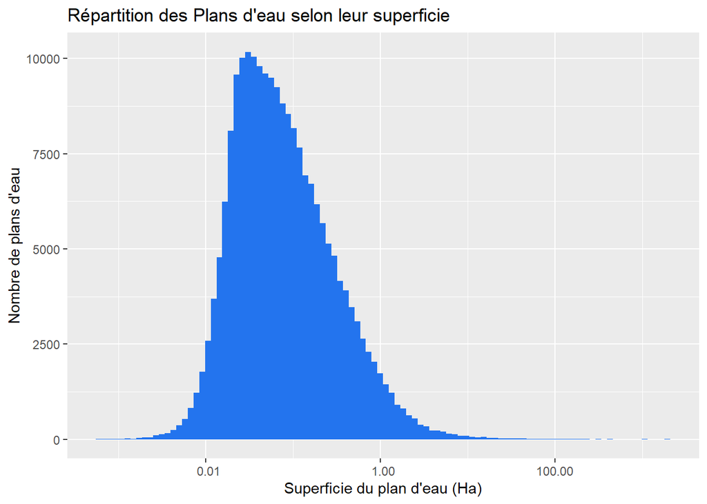

#### Distance au cours d’eau

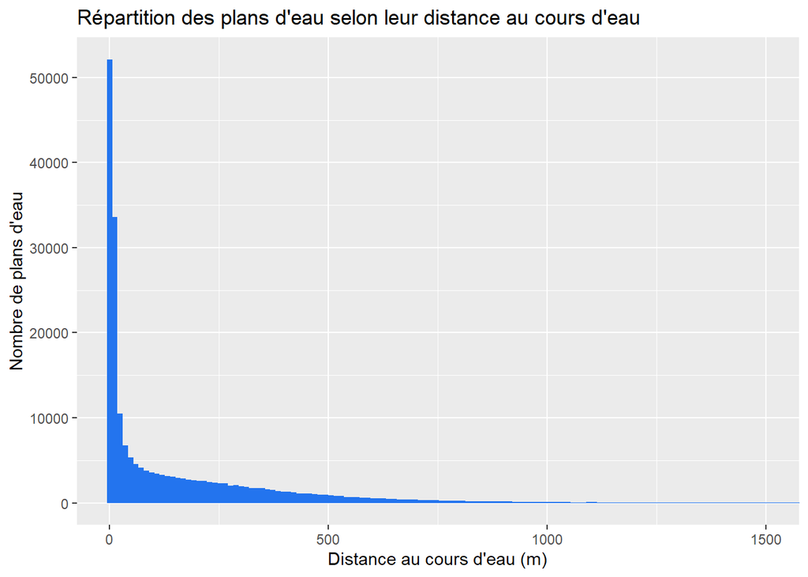

#### Distance à la source

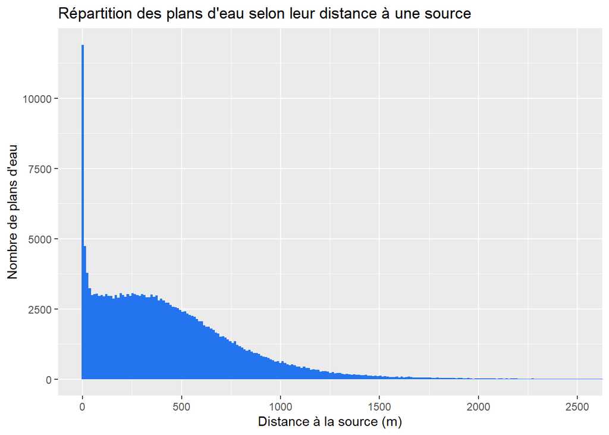

#### Ordination de Strahler

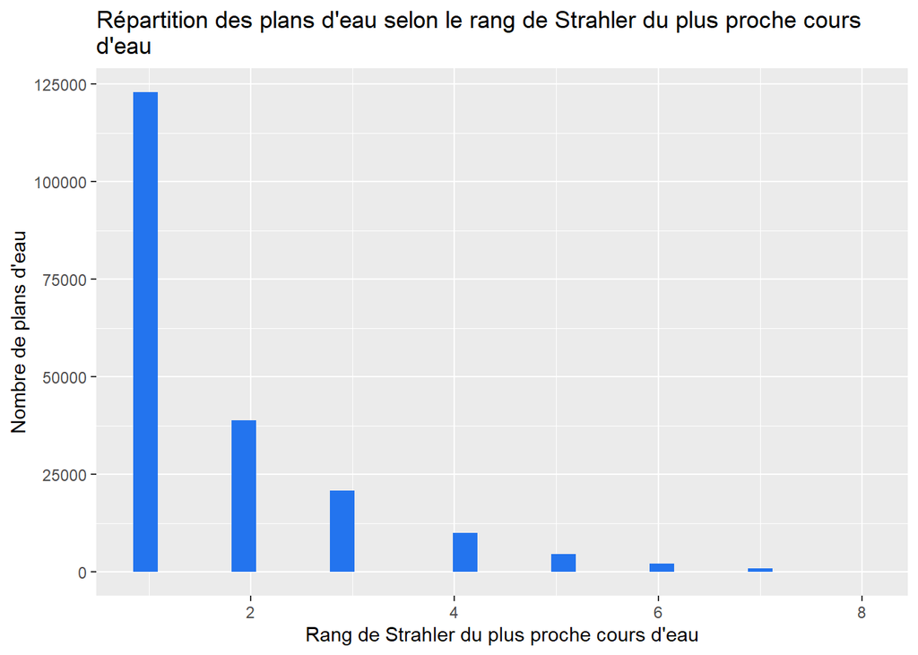

#### Proportion du linéaire hydrographique du bassin versant des masses d’eau intercepté par des plans d’eau

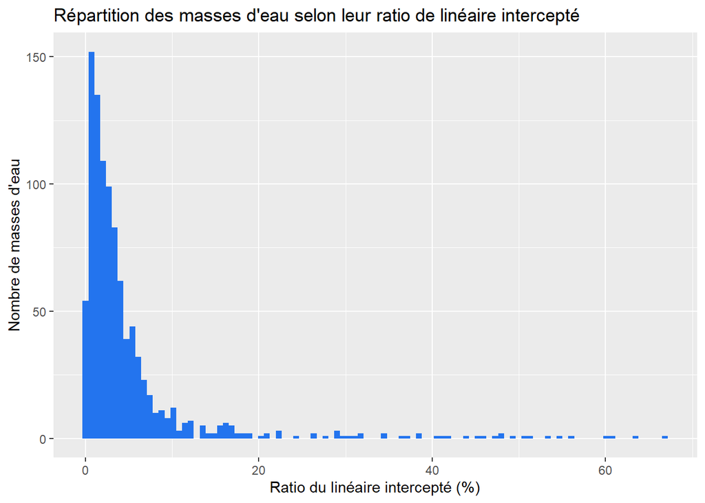

#### Classes lithologiques des surfaces élémentaires de plans d’eau

Voici la carte lithologique simplifiée de la zone d’étude ((c)BRGM).

[figure not shown]

| Lithologie simplifiée | Surface (km²) | Proportion de surface (%) | Surface de marais retenue (km²) | Nombre total de plans d’eau | Densité numérique en plans d’eau par km² | Nombre de plans d’eau hors mares et marais | Densité numérique en plans d’eau hors mares et marais par km² |
| --- | --- | --- | --- | --- | --- | --- | --- |
| Argiles | 6562 | 9.0 | 1 | 21134 | 3.22 | 15270 | 2.33 |
| Basaltes et rhyolites | 1323 | 1.8 | 0 | 3621 | 2.74 | 2608 | 1.97 |
| Calcaires, marne et gypse | 8234 | 11.2 | 16 | 15926 | 1.93 | 11034 | 1.34 |
| Craies | 5937 | 8.1 | 0 | 17501 | 2.95 | 12535 | 2.11 |
| Gneiss | 5273 | 7.2 | 85 | 15505 | 2.94 | 10512 | 2.03 |
| Granites | 13302 | 18.2 | 32 | 34821 | 2.62 | 26872 | 2.02 |
| Micaschistes | 2581 | 3.5 | 27 | 7906 | 3.06 | 5841 | 2.29 |
| Ophiolites | 45 | 0.1 | 10 | 172 | 3.80 | 76 | 2.14 |
| Sables | 3150 | 4.3 | 1157 | 22452 | 7.13 | 5565 | 2.79 |
| Schistes et grès | 26854 | 36.7 | 143 | 69555 | 2.59 | 53477 | 2.00 |

##### Densités selon la lithologie simplifiée

Nous avons apparié par jointure spatiale la lithologie simplifiée aux surfaces élémentaires de plans d’eau.

Nous avons ainsi pu étudier la densité numérique de ces plans d’eau selon le type de lithologie simplifiée :

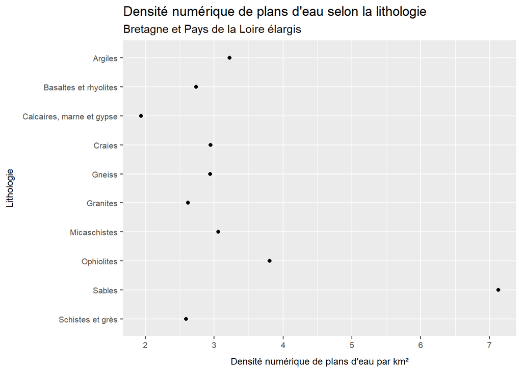

Ainsi que la densité surfacique de ces plans d’eau selon la lithologie simplifiée :

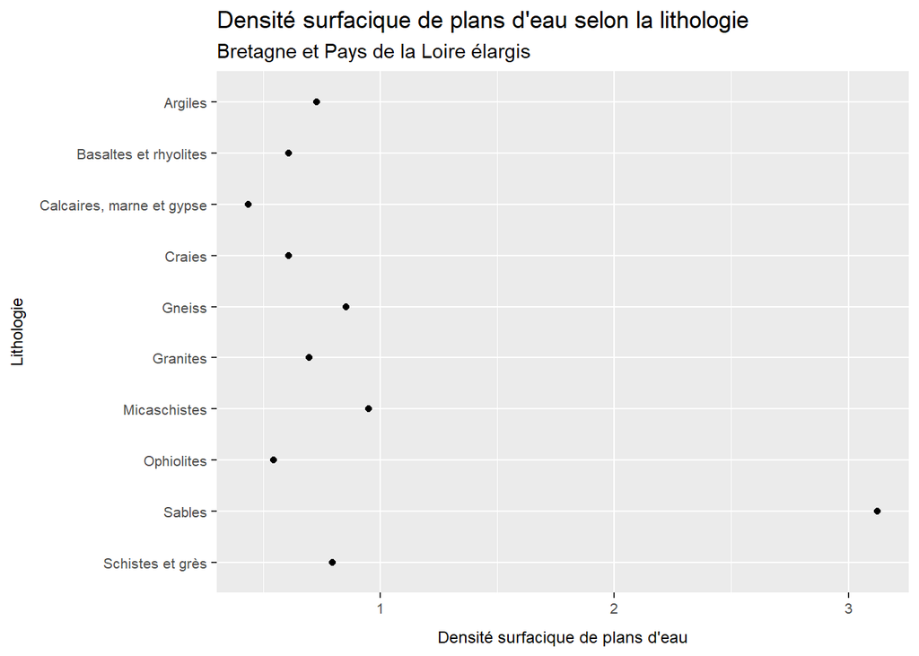

La classe lithologique dont les densités sont les plus fortes est le Sable. Toutefois, nous pouvons ici percevoir l’influence des zones de marais, dont le nombre de surfaces élémentaires est très important.

Nous avons donc recalculé ces densités, sans les surfaces élémentaires de plans d’eau situées en zone de marais (ni les mares) :

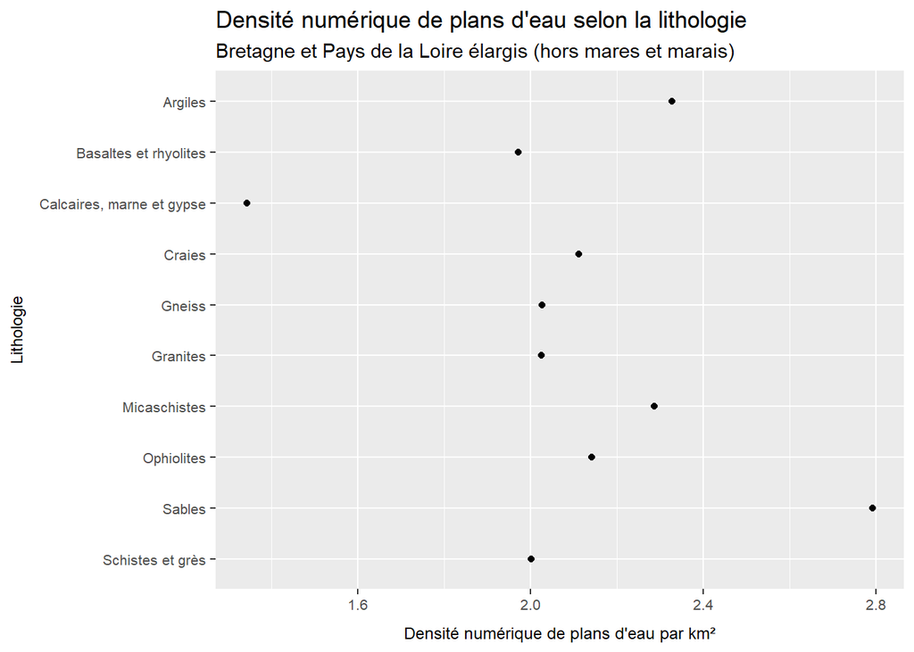

De même pour la densité surfacique :

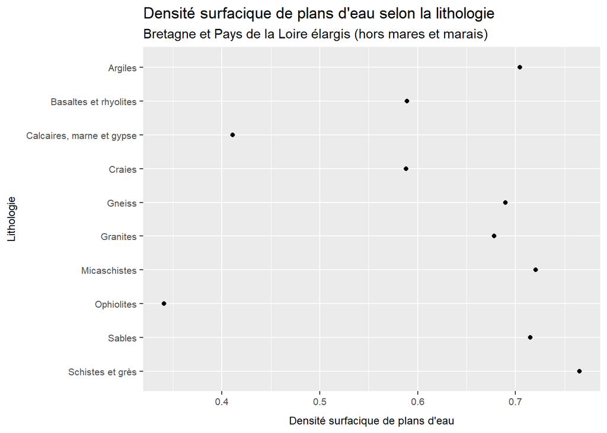

##### Superficie selon la lithologie

Nous avons écarté ici les mares et les marais pour étudier plus spécifiquement la répartition de la superficie des plans d’eau en fonction de leur lithologie.

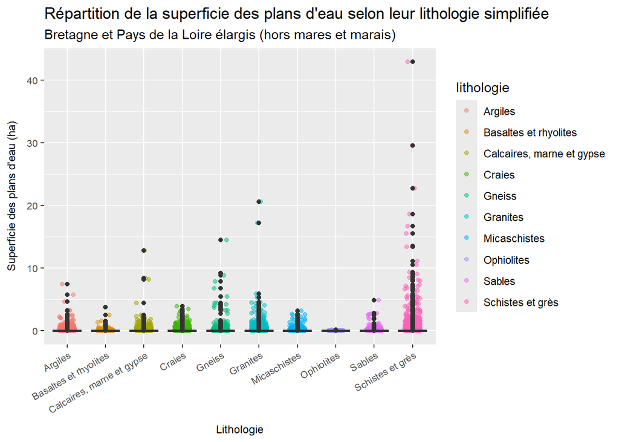

On peut également l’observer sous forme de boîte à moustache (de type violon) :

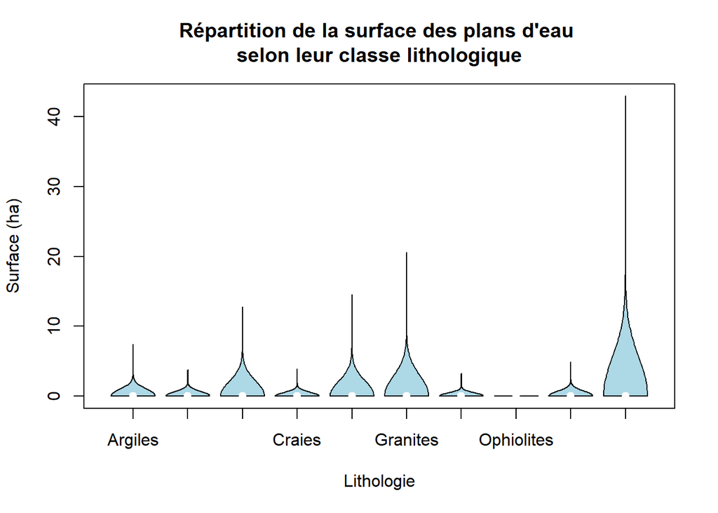

Ou comme au départ, en regardant d’une part la moyenne de ces superficies en fonction des classes lithologiques :

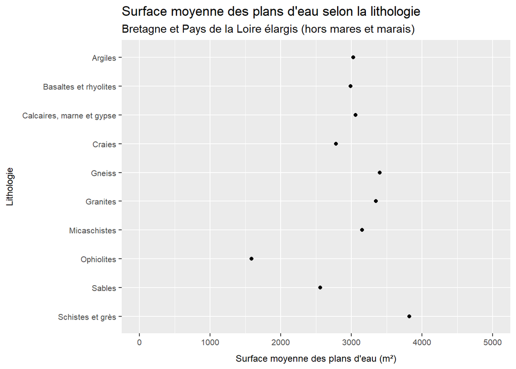

Ainsi que la superficie médiane selon la lithologie :

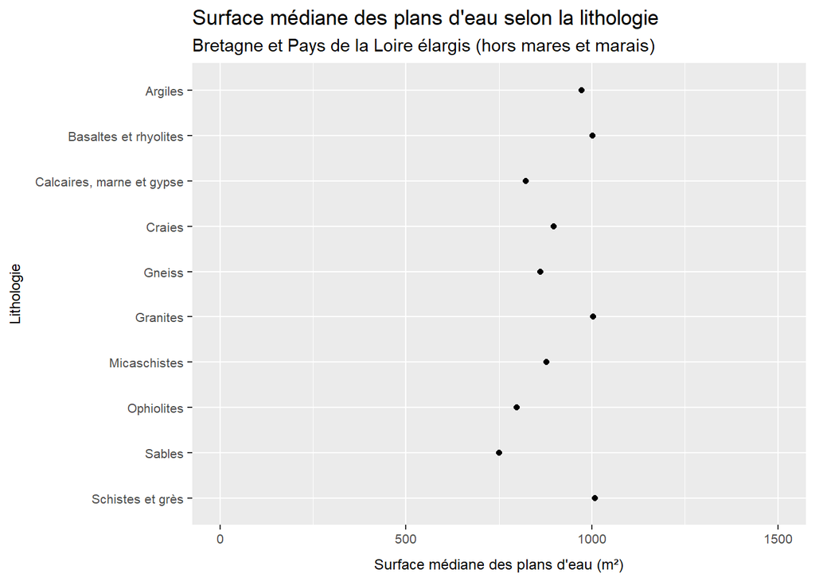

### Trois hypothèses autour de l’implantation des plans d’eau

- L’implantation des plans d’eau est-t-elle liée à la sévérité des étiages ?
- L’implantation des plans d’eau est-t-elle liée au type de masse d’eau (densité plus forte en zone côtière et littorale) ?
- L’implantation des plans d’eau est-t-elle liée au type d’Hydro-Eco-Régions ?

#### L’implantation des plans d’eau est-elle liée à la “sévérité des étiages” ?

Nous avons décidé, pour tester cette hypothèse, d’étudier l’influence du ratio “débit d’étiage sur le débit du module”. Cet indicateur permet en effet de mesurer la vulnérabilité des territoires aux situations d’étiage.

Nous avons apparié aux plans d’eau les débits moyens QMNA5 et QA, issus des cartes de consensus de l’INRAE (https://webgr.inrae.fr/outils/carte-des-debits).

##### “Sévérité des étiages” (ratio q5/qa) de la zone d’étude

[figure not shown]

| Classe de ‘sévérité des étiages’ (ratio q5/qa) | Surface (km²) | Surface retenue de marais (km²) | Proportion de surface (%) | Nombre total de plans d’eau | Densité numérique en plans d’eau par km² | Nombre de plans d’eau (hors mares et marais) | Densité numérique en plans d’eau (hors mares et marais) par km² |
| --- | --- | --- | --- | --- | --- | --- | --- |
| <= 40ème | 18097 | 713 | 24.7 | 79784 | 4.41 | 48945 | 2.82 |
| > 10ème | 24508 | 245 | 33.4 | 54127 | 2.21 | 39103 | 1.61 |
| Entre le 10ème et le 20ème | 17870 | 32 | 24.4 | 38487 | 2.15 | 29556 | 1.66 |
| Entre le 20ème et le 40ème | 12836 | 539 | 17.5 | 34965 | 2.72 | 26170 | 2.13 |

Voici la répartition des bassins versants des masses d’eau et des communes de la zone d’étude en fonction du ratio entre leur plus fort débit d’étiage et leur plus fort débit de module (à l’exutoire pour les masses d’eau) :

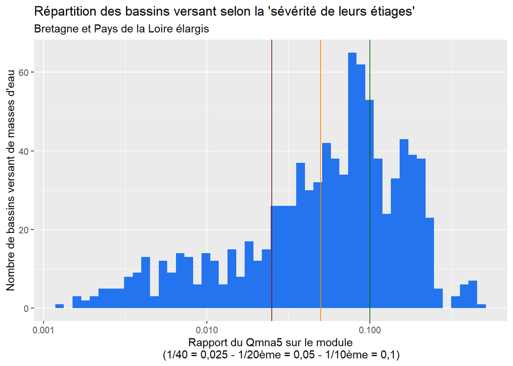

1/40 = 0,025 - 1/20ème = 0,05 - 1/10ème = 0,1

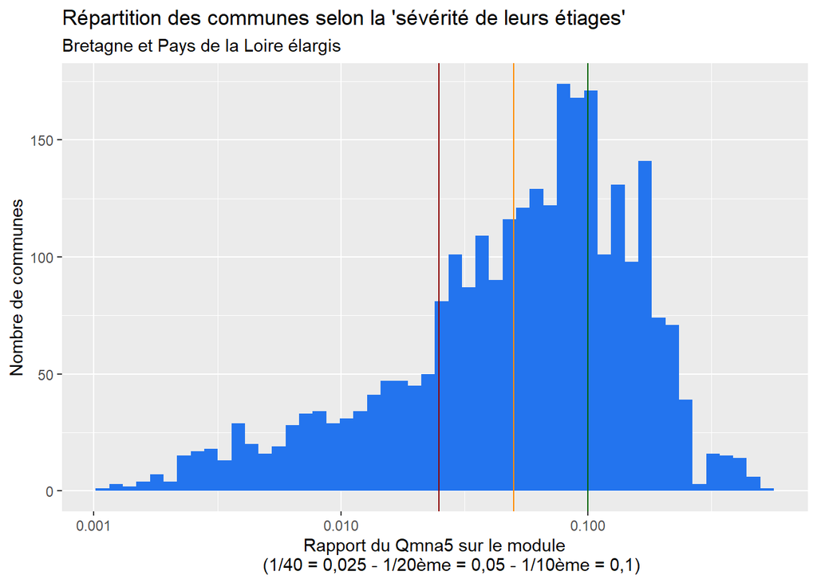

##### Densité en plans d’eau selon ces classes de ratio de débit :

Nous avons calculé, à l’échelle du bassin versant des masses d’eau, les densités en plans d’eau en fonction de 4 principales classes de ratio de débit :

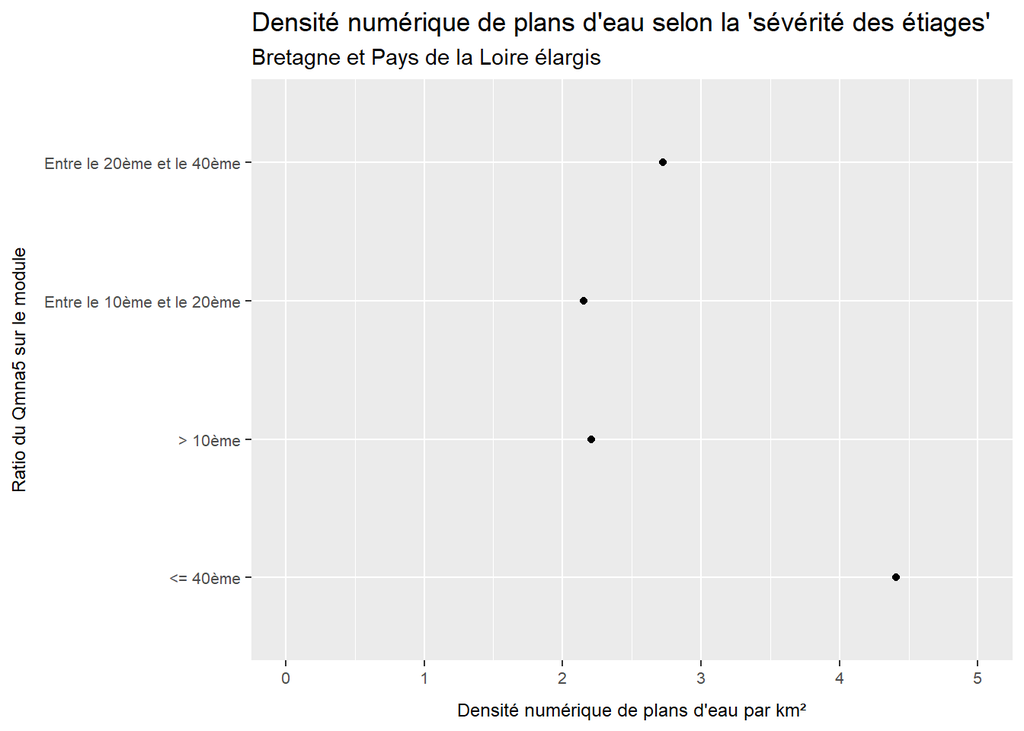

Comparativement, sans les mares et les marais :

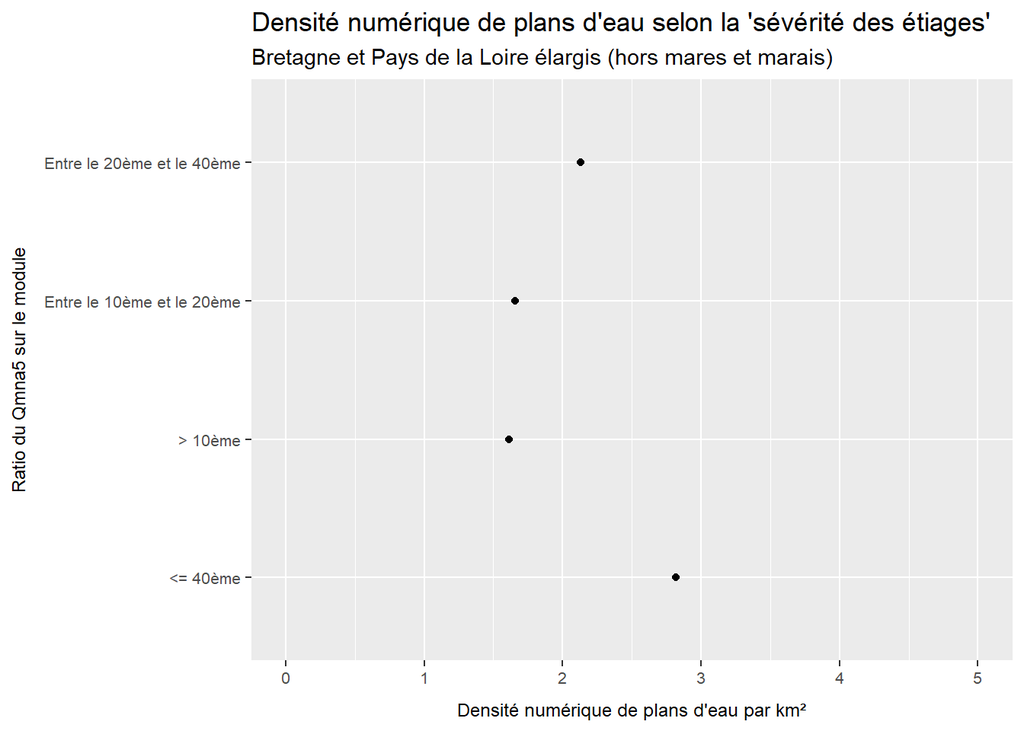

Nous avons également calculé les densité surfaciques :

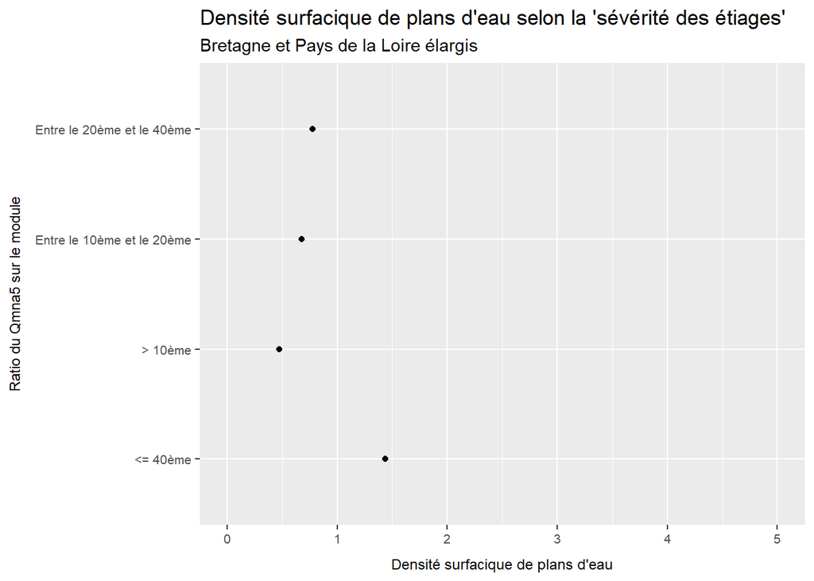

Et de même sans les mares et les marais :

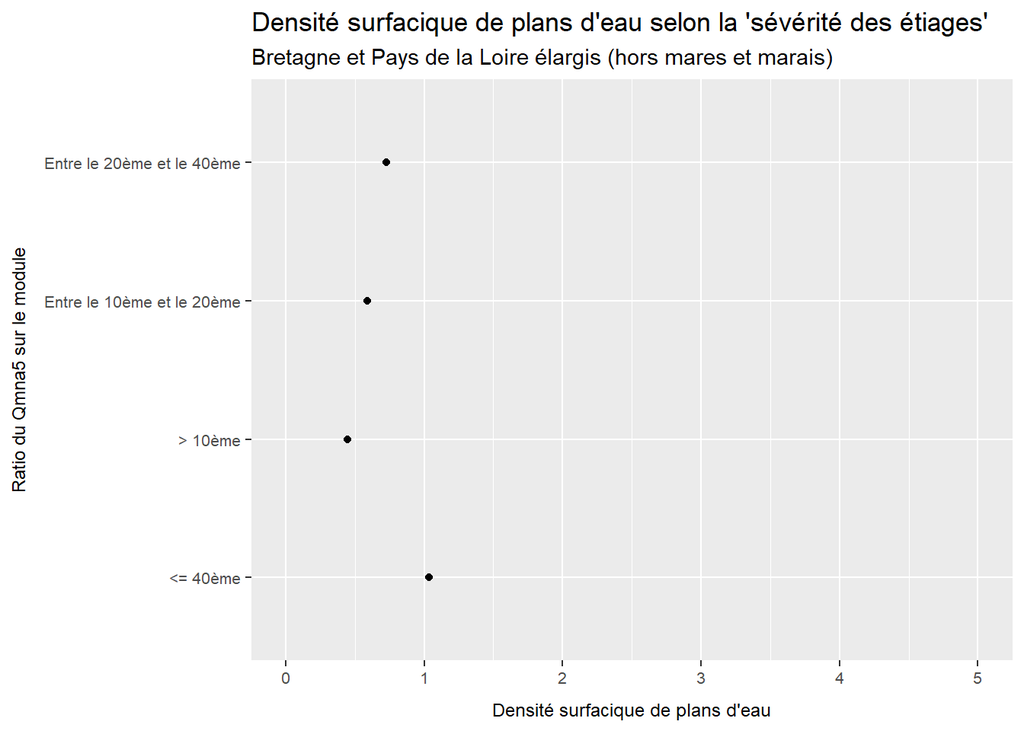

##### Densité numérique en plans d’eau du bassin versant des masses d’eau selon la ‘sévérité de leur étiage’ :

Enfin il nous a paru intéressant de regarder la répartition des densités numériques et surfaciques en plans d’eau (hors mares et marais) du bassin-versant des masses d’eau en fonction de la sévérité de leurs étiages :

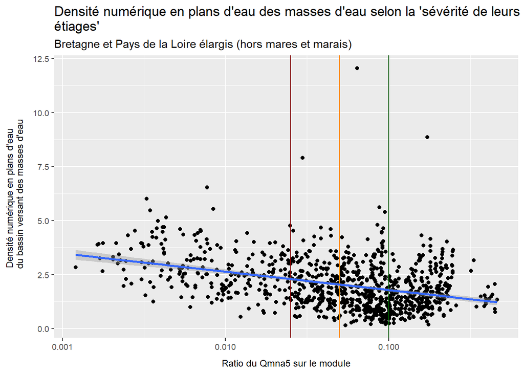

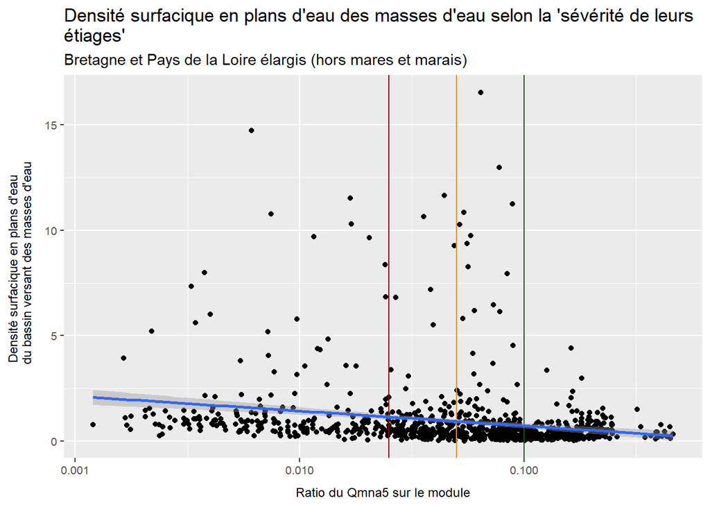

Une analyse statistique du lien de corrélation entre la densité numérique en plans d’eau (hors mares et marais) et le ratio de débit (étiage et module) montre (pour les masses d’eau de type cours d’eau, dont la distance de cook est inférieure à 4/n) que :

- “p-value” < 2.2e-16
- “R² ajusté” = 0.1037

Il existe donc un lien significatif, de relation inverse, entre le ratio de débit et la densité numérique de plans d’eau : les bassins versant des masses d’eau dans lesquels les étiages sont les plus sévères sont également ceux qui statistiquement ont les densités numériques de plan d’eau les plus forte.

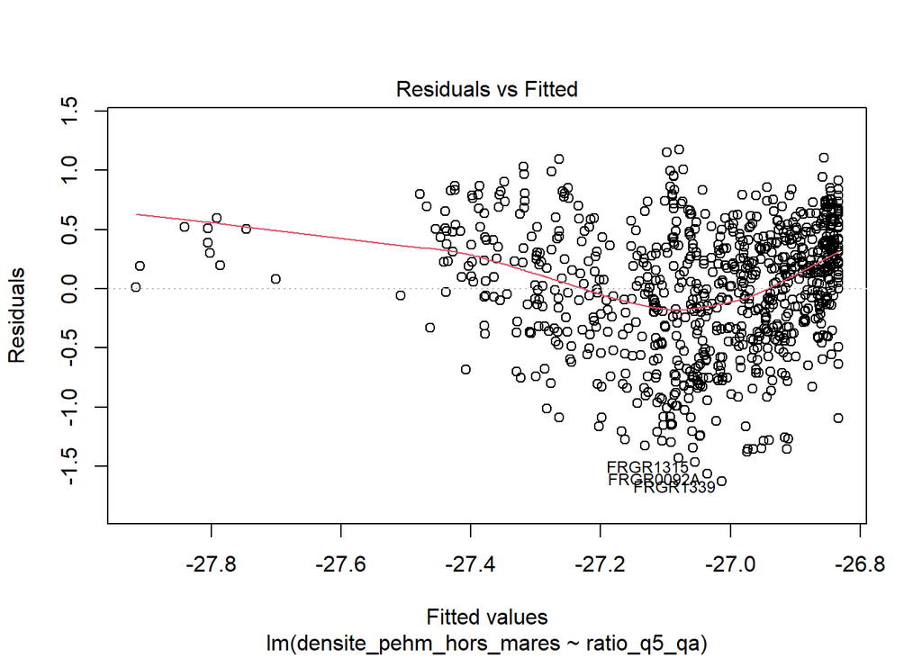

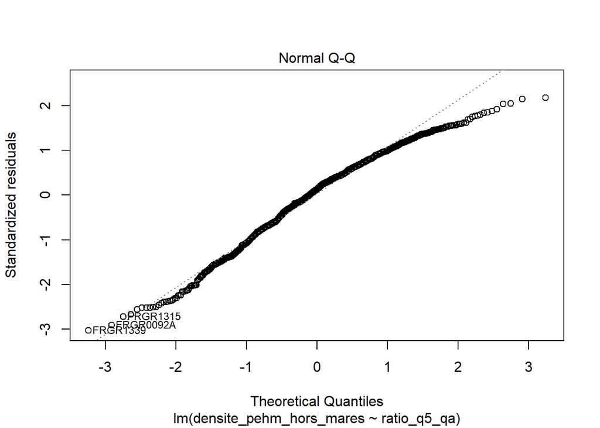

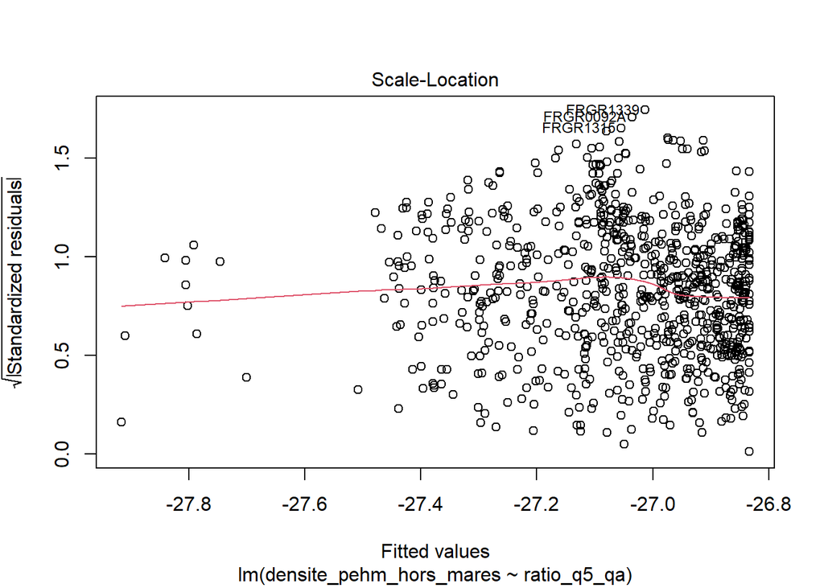

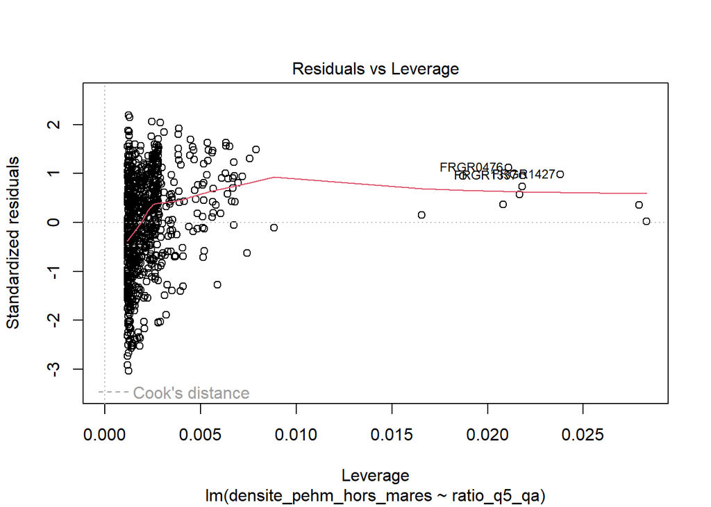

```
##
## Call:
## lm(formula = densite_pehm_hors_mares ~ ratio_q5_qa, data = bv_me_stat_q)
##
## Residuals:
##      Min       1Q   Median       3Q      Max
## -1.62929 -0.36127  0.07138  0.39909  1.17401
##
## Coefficients:
##              Estimate Std. Error  t value Pr(>|t|)
## (Intercept) -26.83350    0.02839 -945.199   <2e-16 ***
## ratio_q5_qa  -2.91552    0.29563   -9.862   <2e-16 ***
## ---
## Signif. codes:  0 '***' 0.001 '**' 0.01 '*' 0.05 '.' 0.1 ' ' 1
##
## Residual standard error: 0.537 on 831 degrees of freedom
## Multiple R-squared:  0.1048, Adjusted R-squared:  0.1037
## F-statistic: 97.26 on 1 and 831 DF,  p-value: < 2.2e-16
```

##### Répartition des plans d’eau selon ce ratio de débit

Voici la répartition des **plans d’eau ayant pu bénéficier d’un appariement de valeurs de débits**, en fonction de leur ratio Q5/Module (30593 surfaces élémentaires de plans d’eau retenues sur 208593 surfaces élémentaires de plans d’eau totales).

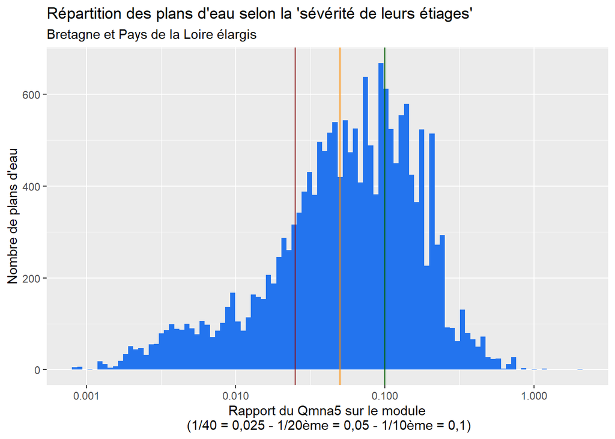

En écartant les mares et les marais :

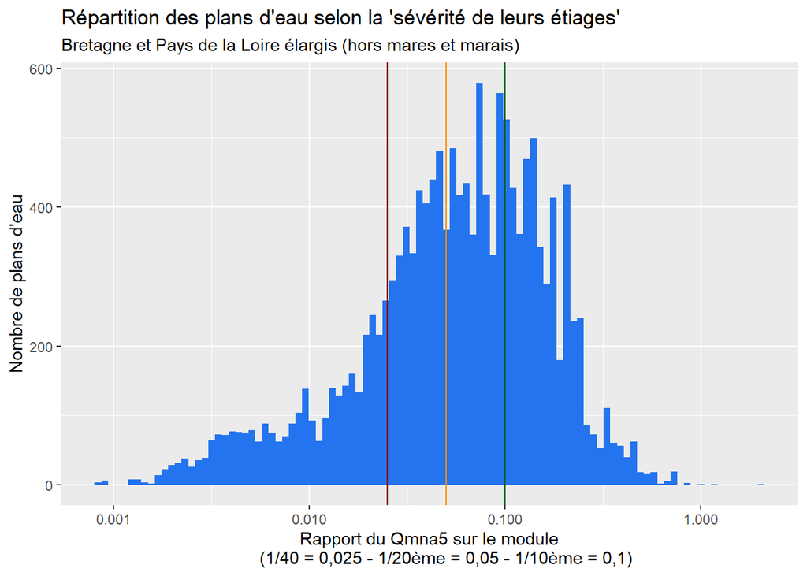